# Predicting Cancer from HPV Positivity and Associated Risk Factors

Cassie Regan, Aiola Cikaj, Faras Sadek

May 4, 2016

# Overview and Motivation

With a collective interest and background experience in public health and cancer, our group decided to focus our project on predicting cancer rates based on HPV positivity and other associated risk factors. It is widely known that HPV infections, when left untreated, can progress into certain cancers. While the percentage of infections that eventually progress is quite low, the risk of progression can be amplified by certain lifestyle choices and habits- such as smoking or parity. In this analysis, we examined the correlation between HPV positivity and various lifestyle choices and tried to predict cancer incidence based on a person’s lifestyle history. We examined many different lifestyle choices to determine which are correlated with HPV and if they have any impact on the eventual progression to cancer. Currently, there is an abundance of data on HPV progression into cervical cancer, but less on HPV progression in other cancers. Additonally, male HPV acquisition and their resulting infections have not been studied in great detail. Since there is little information, we hoped to focus our analysis on all cancers that can be a result of lasting HPV infection.

# Initial Questions

Main Question: Can we use model learning to predict cancer incidence using a training and test set with information on a person’s lifestyle?

Additional questions:

1. What risk factors are associated with HPV positivity? What risk factors are associated with cancer?
2. Are there differences in the incidence and progression of HPV between different cancers?

These questions remained the focus throughout our project. Initially we had hoped to compare and investigate cancer incidence in European countries, but without sufficient publically available data, this was not possible.

# Data

For this analysis we used data from the National Health and Nutrition Examination Survey (NHANES). This data is a nationally representative survey with data on demographics, diet, HPV positivity (from laboratory examination), smoking, income, education, and other lifestyle areas. We combined this data with cancer incidence data from the Surveillance, Epidemiology, and End Results Program (SEER). This data source provides cancer incidence (and other metrics) in the United States. We included incidence rates for Oropharyngeal, Penile, Vaginal, Vulvar, Cervical, and Anal cancer- all of which have been proven to stem from HPV infections. The NHANES dataset is publically available to download in a SAS XPORT form, which can be imported into R for analysis. The SEER data is downloaded through the SEER Stat software and exported in excel format, before being entered into R. The main source of data cleanup comes through wrangling large datasets and moving the data into a usable form.

# Exploratory Analysis

After combining all data into one usable dataset, we were able to begin exploratory analysis. Throughout the data wrangling and clean up, we examined different distributions of risk factors we chose to include in our analysis (diet, smoking history, parity, poverty level, education, martial status, gender, race, diet, and HPV infection). More information on those findings can be found in more detail below. We considered dimention reduction and fit different models using logistic and linear regression. A second order term regression was considered to look for significant interaction. The final model was reached using stepwise regression based on p-values, main effects, and R^2 values.

# Final Analysis

In our analysis we concluded that: On average the number of HPV positive males that will progress to cancer is 0.07 per 10,000 male, or 7 in 1,000,000 all else held constant. This number is only slighlty higher for women, 9 in 1,000,000. The above numbers will change when we control for smoking, education, race, poverty rate, the type of HPV and the number of calories consumed daily. We found a main effect between people who smoke and cancer rate, hispanics and cancer rate and people who don’t have higher eduction and cancer rates. We also tested for different types of diets, but the current data was inconclusive. As a result we ommited the diet variables from the final model. A more in depth analysis between cancer rates and types of diet is suggested for future studies. We answered our questions by establishing a relationship between a person’s lifestyle, cancer rates and high-risk types of HPV. —

# BUILDING NHANES TABLE

```r
library(Hmisc)
library(dplyr)
library(tidyr)

#loading in all files
Demo0506 <- sasxport.get("/Users/aiolaiola/Documents/Development/nocancer/NHANES/DEMO_D2005_2006.XPT")
```

```
## Processing SAS dataset DEMO_D     ..
```

```r
Demo0708 <- sasxport.get("/Users/aiolaiola/Documents/Development/nocancer/NHANES/DEMO_E2007_2008.XPT")
```

```
## Processing SAS dataset DEMO_E     ..
```

```r
Demo0910 <- sasxport.get("/Users/aiolaiola/Documents/Development/nocancer/NHANES/DEMO_F2009_2010.XPT")
```

```
## Processing SAS dataset DEMO_F     ..
```

```r
Demo1112 <- sasxport.get("/Users/aiolaiola/Documents/Development/nocancer/NHANES/DEMO_G2011_2012.XPT")
```

```
## Processing SAS dataset DEMO_G     ..
```

```r
HPV0506 <- sasxport.get("/Users/aiolaiola/Documents/Development/nocancer/NHANES/HPV2005_2006.XPT")
```

```
## Processing SAS dataset HPVSRM_D   ..
```

```r
HPV0708 <- sasxport.get("/Users/aiolaiola/Documents/Development/nocancer/NHANES/HPV2007_2008.XPT")
```

```
## Processing SAS dataset HPVSER_E   ..
```

```r
HPV0910 <- sasxport.get("/Users/aiolaiola/Documents/Development/nocancer/NHANES/HPV2009_2010.XPT")
```

```
## Processing SAS dataset HPVSER_F   ..
```

```r
HPV0506swab <- sasxport.get("/Users/aiolaiola/Documents/Development/nocancer/NHANES/HPVswab2005_2006.XPT")
```

```
## Processing SAS dataset HPVSWR_D   ..
```

```r
HPV0708swab <- sasxport.get("/Users/aiolaiola/Documents/Development/nocancer/NHANES/HPVswab2007_2008.XPT")
```

```
## Processing SAS dataset HPVSWR_E   ..
```

```r
HPV0910swab <- sasxport.get("/Users/aiolaiola/Documents/Development/nocancer/NHANES/HPVswab2009_2010.XPT")
```

```
## Processing SAS dataset HPVSWR_F   ..
```

```r
HPV1112swab <- sasxport.get("/Users/aiolaiola/Documents/Development/nocancer/NHANES/HPVswab2011_2012.XPT")
```

```
## Processing SAS dataset HPVSWR_G   ..
```

```r
HPV0910oral <- sasxport.get("/Users/aiolaiola/Documents/Development/nocancer/NHANES/HPVoral2009_2010.XPT")
```

```
## Processing SAS dataset ORHPV_F    ..
```

```r
HPV1112oral <- sasxport.get("/Users/aiolaiola/Documents/Development/nocancer/NHANES/HPVoral2011_2012.XPT")
```

```
## Processing SAS dataset ORHPV_G    ..
```

```r
diet0506 <- sasxport.get("/Users/aiolaiola/Documents/Development/nocancer/NHANES/diet_2005_2006.XPT")
```

```
## Processing SAS dataset DR1TOT_D   ..
```

```r
diet0708 <- sasxport.get("/Users/aiolaiola/Documents/Development/nocancer/NHANES/diet_2007_2008.XPT")
```

```
## Processing SAS dataset DR1TOT_E   ..
```

```r
diet0910 <- sasxport.get("/Users/aiolaiola/Documents/Development/nocancer/NHANES/diet_2009_2010.XPT")
```

```
## Processing SAS dataset DR1TOT_F   ..
```

```r
diet1112 <- sasxport.get("/Users/aiolaiola/Documents/Development/nocancer/NHANES/diet_2011_2012.XPT")
```

```
## Processing SAS dataset DR1TOT_G   ..
```

```r
smoke0506 <- sasxport.get("/Users/aiolaiola/Documents/Development/nocancer/NHANES/smoke_2005_2006.XPT")
```

```
## Processing SAS dataset SMQ_D      ..
```

```r
smoke0708 <- sasxport.get("/Users/aiolaiola/Documents/Development/nocancer/NHANES/smoke_2007_2008.XPT")
```

```
## Processing SAS dataset SMQ_E      ..
```

```r
smoke0910 <- sasxport.get("/Users/aiolaiola/Documents/Development/nocancer/NHANES/smoke_2009_2010.XPT")
```

```
## Processing SAS dataset SMQ_F      ..
```

```r
smoke1112 <- sasxport.get("/Users/aiolaiola/Documents/Development/nocancer/NHANES/smoke_2011_2012.XPT")
```

```
## Processing SAS dataset SMQ_G      ..
```

```r
rep0506 <- sasxport.get("/Users/aiolaiola/Documents/Development/nocancer/NHANES/reproductive_2005_2006.XPT")
```

```
## Processing SAS dataset RHQ_D      ..
```

```r
rep0708 <- sasxport.get("/Users/aiolaiola/Documents/Development/nocancer/NHANES/reproductive_2007_2008.XPT")
```

```
## Processing SAS dataset RHQ_E      ..
```

```r
rep0910 <- sasxport.get("/Users/aiolaiola/Documents/Development/nocancer/NHANES/reproductive_2009_2010.XPT")
```

```
## Processing SAS dataset RHQ_F      ..
```

```r
rep1112 <- sasxport.get("/Users/aiolaiola/Documents/Development/nocancer/NHANES/reproductive_2011_2012.XPT")
```

```
## Processing SAS dataset RHQ_G      ..
```

```r
Demdiet0506 <- full_join(Demo0506, diet0506)
Demdiet0708 <- full_join(Demo0708, diet0708)
Demdiet0910 <- full_join(Demo0910, diet0910)
Demdiet1112 <- full_join(Demo1112, diet1112)

HPVandSwab0506 <- full_join(HPV0506, HPV0506swab)
HPVandSwab0708 <- full_join(HPV0708, HPV0708swab)
HPVandSwab0910 <- full_join(HPV0910, HPV0910swab)
HPVandSwab1112 <- HPV1112swab

RepSmoke0506 <- full_join(rep0506, smoke0506)
RepSmoke0708 <- full_join(rep0708, smoke0708)
RepSmoke0910 <- full_join(rep0910, smoke0910)
RepSmoke1112 <- full_join(rep1112, smoke1112)



#Merging files
NHANES0506 <- full_join(Demdiet0506, HPVandSwab0506, by = "seqn")
NHANES0506 <- full_join(NHANES0506, RepSmoke0506, by = "seqn")

NHANES0708 <- full_join(Demdiet0708, HPVandSwab0708, by = "seqn")
NHANES0708 <- full_join(NHANES0708, RepSmoke0708, by = "seqn")

NHANES0910 <- full_join(Demdiet0910, HPVandSwab0910, by = "seqn")
NHANES0910 <- full_join(NHANES0910, RepSmoke0910, by = "seqn")
NHANES0910 <- full_join(NHANES0910, HPV0910oral, by ="seqn")

NHANES1112 <- full_join(Demdiet1112, HPVandSwab1112, by = "seqn")
NHANES1112 <- full_join(NHANES1112, RepSmoke1112, by = "seqn")
NHANES1112 <- full_join(NHANES1112, HPV1112oral, by ="seqn")


#Adding years- NOTE: using second year as indicator, but survey spans 2 years
NHANES0506$year <- "2006"
NHANES0708$year <- "2008"
NHANES0910$year <- "2010"
NHANES1112$year <- "2012"

#creating master NHANES dataset
NHANES <- merge(NHANES0506, NHANES0708, all = TRUE)
NHANES <- merge(NHANES, NHANES0910, all = TRUE)
NHANES <- merge(NHANES, NHANES1112, all = TRUE)

save(NHANES, file = "NHANES.Rda")
```

```r
rm(list= ls()[!(ls() %in% c('NHANES','all_gather', 'cancer_types', 'dat'))])

NHANES <- NHANES %>%
  select(c(seqn, wtdrd1, drqsdiet, drqsdt1, drqsdt2, drqsdt3, drqsdt4, drqsdt5, drqsdt6, drqsdt7, drqsdt8, drqsdt91, dr1tkcal, riagendr, ridageyr, ridreth1, wtmec2yr, sdmvpsu, sdmvstra, lbdr06, lbdr11, lbdr16, lbdr18, lbdr31, lbdr33, lbdr45, lbdr52, lbdr58, orxh16, rhq166, rhq160, smq040, year, dmdeduc2, dmdmartl, indfmpir))

#Changing column names
names(NHANES) <- c("respID", "dietweight", "specialdiet", "weightloss_lowcal_lowcarb_hipro", "lowfat", "lowNA", "sugfree", "lowfiber", "hifiber", "diabeticdiet", "weightgain", "othrediet", "kcal", "gender", "age", "race", "examwt", "PSU", "stratum", "hpv6", "hpv11", "hpv16", "hpv18", "hpv31", "hpv33", "hpv45", "hpv52", "hpv58", "oralhpv16", "numbirth", "numpreg", "smoke" ,"year", "education", "marital_status", "poverty_ratio")
```

## Recoding for gender and filtering for age:

```r
## matching Male and Female coding to the SEER table
NHANES$gender.f = factor(NHANES$gender, labels = c(1, 0))

NHANES <- NHANES %>% select(-c(gender, PSU, stratum))

## filtering out for 0-15 years:

NHANES$age <- as.numeric(NHANES$age)

NHANES <- NHANES %>% filter(age >= 15)
```

## Recoding HPV variables:

```r
tmp <- NHANES %>% select(respID, contains("hpv"))

## 1 for hpv positive and 0 for negative.
tmp <- as.matrix(tmp)
tmp[tmp == 2] <- 0
tmp[tmp == 3] <- 0
tmp[is.na(tmp)] <- 0

tmp <- data.frame(tmp)

NHANES <- NHANES %>% select(-(contains("hpv")))
NHANES <- left_join(NHANES, tmp, by = "respID")

rm(tmp)
```

## Recoding diet variables:

```r
tmp <- NHANES %>% select(respID, weightloss_lowcal_lowcarb_hipro, lowfat, lowNA, sugfree, lowfiber, hifiber, diabeticdiet, weightgain, othrediet)

## 1 for being on the specific diet and 0 for negative or missing.
tmp <- as.matrix(tmp)
tmp[tmp > 1 & tmp < 3000] <- 1
tmp[is.na(tmp)] <- 0

tmp <- data.frame(tmp)

NHANES <- NHANES %>% select(-c(weightloss_lowcal_lowcarb_hipro, lowfat, lowNA, sugfree, lowfiber, hifiber, diabeticdiet, weightgain, othrediet))

NHANES <- left_join(NHANES, tmp, by = "respID")

rm(tmp)
```

## Cleaning up other variables:

```r
#NHANES <- NHANES %>% select(- age_at_exam)

## 1 for being on a special diet and o for negative
NHANES$specialdiet[NHANES$specialdiet == 2] <- 0
NHANES$specialdiet[NHANES$specialdiet == 9] <- NA
```

## HPV count for each year

```r
NHANES_year <- NHANES %>% group_by(year) %>% summarize(c.hpv6= sum(hpv6), c.hpv11= sum(hpv11), c.hpv16= sum(hpv16), c.hpv18= sum(hpv18), c.hpv31= sum(hpv31), c.hpv33= sum(hpv33), c.hpv45= sum(hpv45), c.hpv52=sum(hpv52), c.hpv58= sum(hpv58), c.oralhpv16= sum(oralhpv16))


NHANES <- NHANES %>% select(-contains("hpv")) %>% left_join(NHANES_year, by= "year")
```

# BUILDING SEER

```r
library(readxl)
library(foreign)
library(gdata)
library(tidyr)
library(dplyr)
library(readr)

#loading in files

oro <- read_csv("/Users/aiolaiola/Documents/Development/nocancer/oro.csv")
penile <- read_csv("/Users/aiolaiola/Documents/Development/nocancer/penile.csv")
vaginal <- read_csv("/Users/aiolaiola/Documents/Development/nocancer/vaginal.csv")
vulvar <- read_csv("/Users/aiolaiola/Documents/Development/nocancer/vulvar.csv")
cervical <- read_csv("/Users/aiolaiola/Documents/Development/nocancer/cervical.csv")
anal <- read_csv("/Users/aiolaiola/Documents/Development/nocancer/anal.csv")

#wrangling- renaming columns
names(oro) <- c("gender.f", "type", "age", "2000_rate", "2000_count", "2000_population", "2001_rate", "2001_count", "2001_population", "2002_rate", "2002_count", "2002_population", "2003_rate", "2003_count", "2003_population", "2004_rate", "2004_count", "2004_population", "2005_rate", "2005_count", "2005_population", "2006_rate", "2006_count", "2006_population", "2007_rate", "2007_count", "2007_population", "2008_rate", "2008_count", "2008_population", "2009_rate", "2009_count", "2009_population", "2010_rate", "2010_count", "2010_population", "2011_rate", "2011_count", "2011_population", "2012_rate", "2012_count", "2012_population")
oro <- oro[-1,]

names(penile) <- c("gender.f", "type", "age", "2000_rate", "2000_count", "2000_population", "2001_rate", "2001_count", "2001_population", "2002_rate", "2002_count", "2002_population", "2003_rate", "2003_count", "2003_population", "2004_rate", "2004_count", "2004_population", "2005_rate", "2005_count", "2005_population", "2006_rate", "2006_count", "2006_population", "2007_rate", "2007_count", "2007_population", "2008_rate", "2008_count", "2008_population", "2009_rate", "2009_count", "2009_population", "2010_rate", "2010_count", "2010_population", "2011_rate", "2011_count", "2011_population", "2012_rate", "2012_count", "2012_population")
penile <- penile[-1,]

names(vaginal) <- c("gender.f", "type", "age", "2000_rate", "2000_count", "2000_population", "2001_rate", "2001_count", "2001_population", "2002_rate", "2002_count", "2002_population", "2003_rate", "2003_count", "2003_population", "2004_rate", "2004_count", "2004_population", "2005_rate", "2005_count", "2005_population", "2006_rate", "2006_count", "2006_population", "2007_rate", "2007_count", "2007_population", "2008_rate", "2008_count", "2008_population", "2009_rate", "2009_count", "2009_population", "2010_rate", "2010_count", "2010_population", "2011_rate", "2011_count", "2011_population", "2012_rate", "2012_count", "2012_population")
vaginal <- vaginal[-1,]

names(vulvar) <- c("gender.f", "type", "age", "2000_rate", "2000_count", "2000_population", "2001_rate", "2001_count", "2001_population", "2002_rate", "2002_count", "2002_population", "2003_rate", "2003_count", "2003_population", "2004_rate", "2004_count", "2004_population", "2005_rate", "2005_count", "2005_population", "2006_rate", "2006_count", "2006_population", "2007_rate", "2007_count", "2007_population", "2008_rate", "2008_count", "2008_population", "2009_rate", "2009_count", "2009_population", "2010_rate", "2010_count", "2010_population", "2011_rate", "2011_count", "2011_population", "2012_rate", "2012_count", "2012_population")
vulvar <- vulvar[-1,]

names(cervical) <- c("gender.f", "type", "age", "2000_rate", "2000_count", "2000_population", "2001_rate", "2001_count", "2001_population", "2002_rate", "2002_count", "2002_population", "2003_rate", "2003_count", "2003_population", "2004_rate", "2004_count", "2004_population", "2005_rate", "2005_count", "2005_population", "2006_rate", "2006_count", "2006_population", "2007_rate", "2007_count", "2007_population", "2008_rate", "2008_count", "2008_population", "2009_rate", "2009_count", "2009_population", "2010_rate", "2010_count", "2010_population", "2011_rate", "2011_count", "2011_population", "2012_rate", "2012_count", "2012_population")
cervical <- cervical[-1,]

names(anal) <- c("gender.f", "type", "age", "2000_rate", "2000_count", "2000_population", "2001_rate", "2001_count", "2001_population", "2002_rate", "2002_count", "2002_population", "2003_rate", "2003_count", "2003_population", "2004_rate", "2004_count", "2004_population", "2005_rate", "2005_count", "2005_population", "2006_rate", "2006_count", "2006_population", "2007_rate", "2007_count", "2007_population", "2008_rate", "2008_count", "2008_population", "2009_rate", "2009_count", "2009_population", "2010_rate", "2010_count", "2010_population", "2011_rate", "2011_count", "2011_population", "2012_rate", "2012_count", "2012_population")
anal <- anal[-1,]


#adding organ column
oro <- oro%>%
  mutate(organ = "oro")

penile <- penile%>%
  mutate(organ = "penile")

vaginal <- vaginal%>%
  mutate(organ = "vaginal")

vulvar <- vulvar%>%
  mutate(organ = "vulvar")

cervical <- cervical%>%
  mutate(organ = "cervical")

anal <- anal%>%
  mutate(organ = "anal")

#merging to combine organ datasets
seer <- rbind(oro, penile)
seer <- rbind(seer, vaginal)
seer <- rbind(seer, vulvar)
seer <- rbind(seer, cervical)
seer <- rbind(seer, anal)

#separating by year to make separate columns for rate, count, population, and year
seer00<- seer %>%
  select(contains("2000"), gender.f, type, age, organ)%>%
  mutate(year = "2000")

names(seer00) <- c("rate", "count", "population", "gender.f", "type", "age", "organ", "year")

seer01<- seer %>%
  select(contains("2001"), gender.f, type, age, organ)%>%
  mutate(year = "2001")
names(seer01) <- c("rate", "count", "population", "gender.f", "type", "age", "organ", "year")

seer02<- seer %>%
  select(contains("2002"), gender.f, type, age, organ)%>%
  mutate(year = "2002")
names(seer02) <- c("rate", "count", "population", "gender.f", "type", "age", "organ", "year")

seer03<- seer %>%
  select(contains("2003"), gender.f, type, age, organ)%>%
  mutate(year = "2003")
names(seer03) <- c("rate", "count", "population", "gender.f", "type", "age", "organ", "year")

seer04<- seer %>%
  select(contains("2004"), gender.f, type, age, organ)%>%
  mutate(year = "2004")
names(seer04) <- c("rate", "count", "population", "gender.f", "type", "age", "organ", "year")

seer05<- seer %>%
  select(contains("2005"), gender.f, type, age, organ)%>%
  mutate(year = "2005")
names(seer05) <- c("rate", "count", "population", "gender.f", "type", "age", "organ", "year")

seer06<- seer %>%
  select(contains("2006"), gender.f, type, age, organ)%>%
  mutate(year = "2006")
names(seer06) <- c("rate", "count", "population", "gender.f", "type", "age", "organ", "year")

seer07<- seer %>%
  select(contains("2007"), gender.f, type, age, organ)%>%
  mutate(year = "2007")
names(seer07) <- c("rate", "count", "population", "gender.f", "type", "age", "organ", "year")

seer08<- seer %>%
  select(contains("2008"), gender.f, type, age, organ)%>%
  mutate(year = "2008")
names(seer08) <- c("rate", "count", "population", "gender.f", "type", "age", "organ", "year")

seer09<- seer %>%
  select(contains("2009"), gender.f, type, age, organ)%>%
  mutate(year = "2009")
names(seer09) <- c("rate", "count", "population", "gender.f", "type", "age", "organ", "year")

seer10<- seer %>%
  select(contains("2010"), gender.f, type, age, organ)%>%
  mutate(year = "2010")
names(seer10) <- c("rate", "count", "population", "gender.f", "type", "age", "organ", "year")

seer11<- seer %>%
  select(contains("2011"), gender.f, type, age, organ)%>%
  mutate(year = "2011")
names(seer11) <- c("rate", "count", "population", "gender.f", "type", "age", "organ", "year")

seer12<- seer %>%
  select(contains("2012"), gender.f, type, age, organ)%>%
  mutate(year = "2012")
names(seer12) <- c("rate", "count", "population", "gender.f", "type", "age", "organ", "year")

#merging to create new complete SEER dataset
seer_new <- rbind(seer00, seer01, all=TRUE)
seer_new <- rbind(seer_new, seer02, all = TRUE)
seer_new <- rbind(seer_new, seer03, all = TRUE)
seer_new <- rbind(seer_new, seer04, all = TRUE)
seer_new <- rbind(seer_new, seer05, all = TRUE)
seer_new <- rbind(seer_new, seer06, all = TRUE)
seer_new <- rbind(seer_new, seer07, all = TRUE)
seer_new <- rbind(seer_new, seer08, all = TRUE)
seer_new <- rbind(seer_new, seer09, all = TRUE)
seer_new <- rbind(seer_new, seer10, all = TRUE)
seer_new <- rbind(seer_new, seer11, all = TRUE)
seer_new <- rbind(seer_new, seer12, all = TRUE)

#removing added extra row
seer_new <- seer_new[-8904,]
```

```r
library(ggplot2)
library(dplyr)
library(broom)

rm(anal, cervical, oro, penile, seer, seer00, seer01, seer02, seer03, seer04, seer05, seer06, seer07, seer08, seer09, seer10, seer11, seer12, vulvar, vaginal)


seer_new <- seer_new %>% filter(type== "SCC")

## recoding the gender variable into "Female"=0, "Male"=1, "Male and Female"= 2
seer_new$gender.f = factor(seer_new$gender.f, labels = c(0, 1, 2))


## changing the class for all_gather$rate and all_gather$population into numeric

sapply(seer_new, class)
```

```
##        rate       count  population    gender.f        type         age
## "character" "character" "character"    "factor" "character" "character"
##       organ        year
## "character" "character"
```

```r
seer_new$rate <- as.numeric(seer_new$rate)
seer_new$population <- as.numeric(gsub(",", "", seer_new$population))

## filtering out for 0-15 years:

seer_new$age.f = factor(seer_new$age)

seer_new <- seer_new %>% select(-c(age, type))

seer_new <- seer_new %>% filter(age.f != "00 years")
seer_new <- seer_new  %>% filter(age.f != "01-04 years")
seer_new <- seer_new %>% filter(age.f != "05-09 years")
seer_new <- seer_new %>% filter(age.f != "10-14 years")



## switch organ variable to a factor:
seer_new$organ <- factor(seer_new$organ)
```

## Analyzing the differences between Male and Female:

```r
## quick summary of the  mean for each gender group:

seer_new %>% group_by(gender.f) %>% summarize(c(mean(rate)))
```

```
## Source: local data frame [3 x 2]
##
##   gender.f c(mean(rate))
##     (fctr)         (dbl)
## 1        0     1.9876923
## 2        1     0.6130769
## 3        2     1.4325641
```

```r
seer_new %>% group_by(gender.f) %>% summarize(c(mean(population)))
```

```
## Source: local data frame [3 x 2]
##
##   gender.f c(mean(population))
##     (fctr)               (dbl)
## 1        0            761915.7
## 2        1            725034.5
## 3        2           1486950.1
```

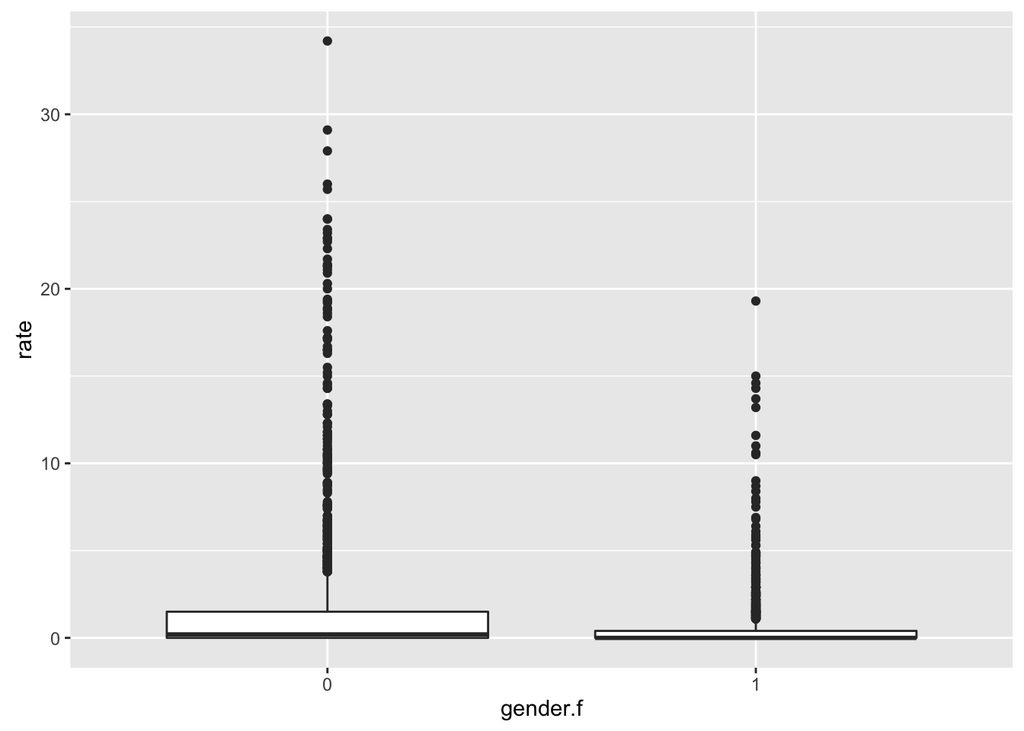

```r
## filtering out "MAle and Female" group in order to determine if there is a statistically significant difference in means between Male and Female for the rate and population variables:

seer <- seer_new %>% filter(gender.f != 2)

## for the rate variable:
seer %>% ggplot(aes(gender.f, rate)) + geom_boxplot()
```

```r
t.test(rate ~ gender.f, data= seer)
```

```
##
##  Welch Two Sample t-test
##
## data:  rate by gender.f
## t = 9.9429, df = 1500.2, p-value < 2.2e-16
## alternative hypothesis: true difference in means is not equal to 0
## 95 percent confidence interval:
##  1.103428 1.645802
## sample estimates:
## mean in group 0 mean in group 1
##       1.9876923       0.6130769
```

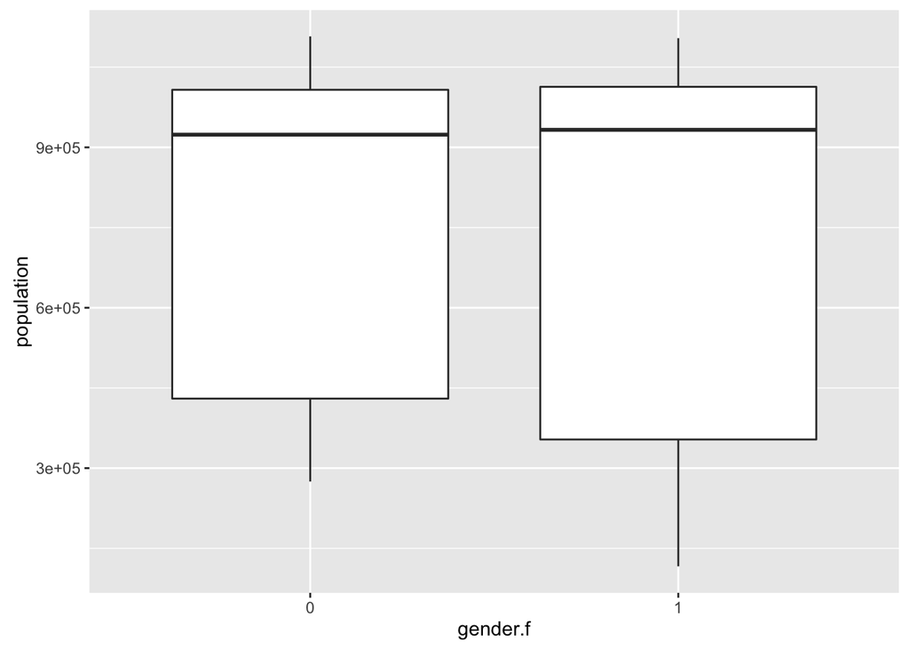

```r
## The t-test shows that the p- value is smaller then 0.05 and 0 is not included the in the ##confidence interval.
## This means that we can reject the null hypothesis and conclude that there is a statistically ##significant difference in the means of the rate of malignant cancer due
##to HPV between Male and Female.

## for the population variable:
seer %>% ggplot(aes(gender.f, population)) + geom_boxplot()
```

```r
t.test(population ~ gender.f, data= seer)
```

```
##
##  Welch Two Sample t-test
##
## data:  population by gender.f
## t = 2.8266, df = 2282.9, p-value = 0.004745
## alternative hypothesis: true difference in means is not equal to 0
## 95 percent confidence interval:
##  11294.34 62468.02
## sample estimates:
## mean in group 0 mean in group 1
##        761915.7        725034.5
```

```r
## Similar to the t-test for rate, the t-test for population shows that there is a statistically significant difference in means between males and females for the proprotion of the U.S population included in the data set. Note: This could also explain the difference in means for the rate
```

## Comparison between Male and Female for different types of cancer.

```r
cancer_types <- seer %>% group_by(organ,gender.f) %>% summarize(mean=mean(rate)) %>% arrange(desc(mean))

cancer_types
```

```
## Source: local data frame [12 x 3]
## Groups: organ [6]
##
##       organ gender.f      mean
##      (fctr)   (fctr)     (dbl)
## 1      anal        0 1.6235897
## 2      anal        1 1.2492308
## 3  cervical        0 6.6010256
## 4  cervical        1 0.0000000
## 5       oro        1 0.7405128
## 6       oro        0 0.2271795
## 7    penile        1 1.6887179
## 8    penile        0 0.0000000
## 9   vaginal        0 0.7056410
## 10  vaginal        1 0.0000000
## 11   vulvar        0 2.7687179
## 12   vulvar        1 0.0000000
```

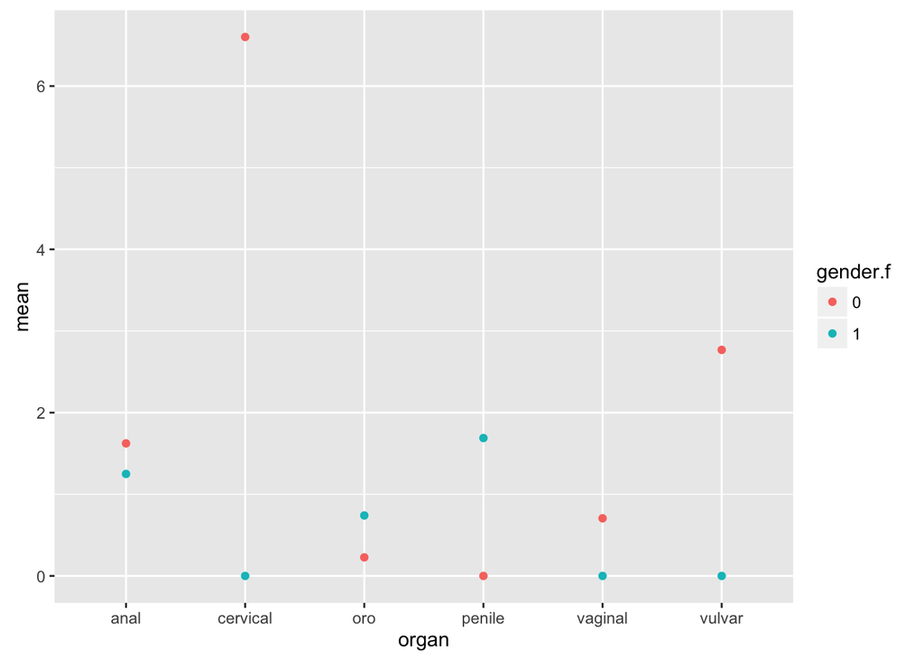

```r
cancer_types %>% ggplot(aes(organ, mean, color= gender.f)) + geom_point()
```

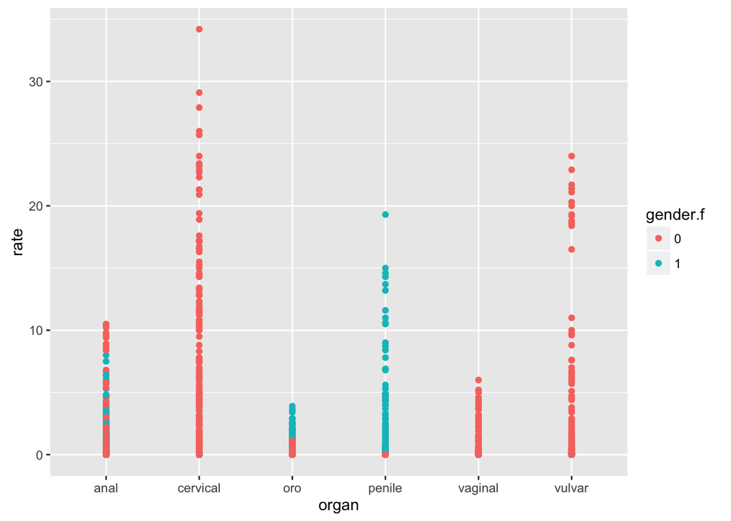

```r
seer %>% ggplot(aes(organ, rate, color= gender.f)) + geom_point()
```

## Adding up the count and population for each year, gender and organ:

```r
sapply(seer,class)
```

```
##        rate       count  population    gender.f       organ        year
##   "numeric" "character"   "numeric"    "factor"    "factor" "character"
##       age.f
##    "factor"
```

```r
seer$count <- as.numeric(seer$count)

dat <- seer %>% select(-age.f) %>% group_by(year,gender.f, organ) %>% summarize(count= sum(count), pop= sum(population))
```

## Joining SEER and NHANES:

```r
hpv <- merge(dat, NHANES, by = c("year", "gender.f"), all=TRUE)

hpv <- hpv %>% select(-c(dietweight,examwt))

hpv06 <- hpv %>%filter(year =="2006")
hpv08 <- hpv %>%filter(year =="2008")
hpv10 <- hpv %>%filter(year =="2010")
hpv12 <- hpv %>% filter(year == "2012")

hpv <- merge(hpv06, hpv08, all=TRUE)
hpv <- merge(hpv, hpv10, all=TRUE)
hpv <- merge(hpv, hpv12, all=TRUE)
```

## creating rate variable for 10,000 pop

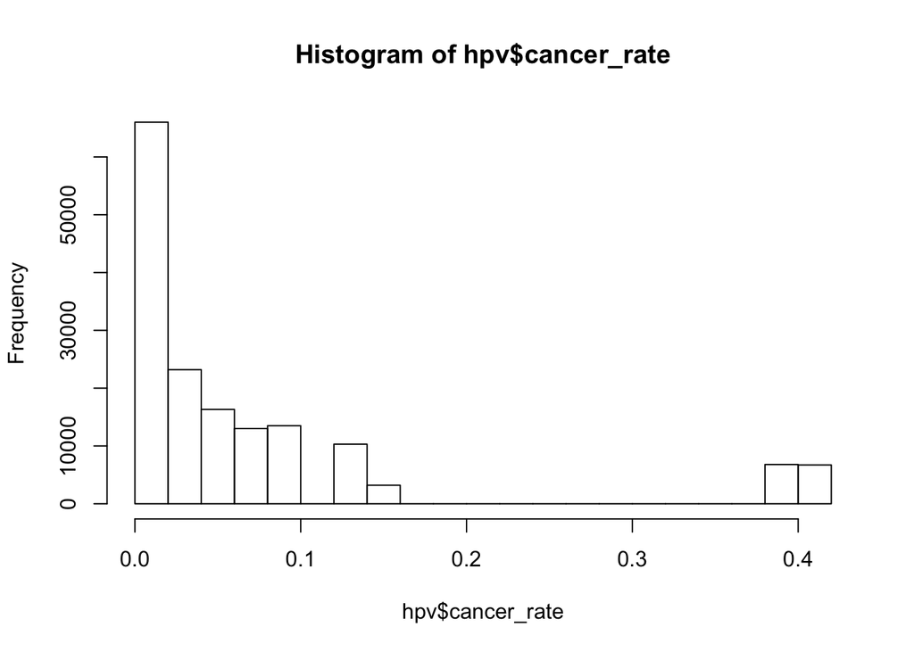

```r
hpv <- hpv %>% mutate(cancer_rate= round((count/pop)*10^4, digits = 2))
hist(hpv$cancer_rate)
```

```r
summary(hpv$cancer_rate)
```

```
##    Min. 1st Qu.  Median    Mean 3rd Qu.    Max.
## 0.00000 0.00000 0.04000 0.07287 0.09000 0.42000
```

```r
hpv <- hpv %>% mutate(cancer_count= count) %>% mutate(nocancer = (pop - count))

save(hpv, file= "hpv.Rda")
```

## Naive model

```r
## codes for smoking:
## 1    Every day
## 2    Some days
## 3    Not at all
## 7    Refused
## 9    Don't know

## Codes for education:
## 1    Less Than 9th Grade
## 2    9-11th Grade (Includes 12th grade with no diploma)
## 3    High School Grad/GED or Equivalent
## 4    Some College or AA degree
## 5    College Graduate or above
## 7    Refused
## 9    Don't Know

## Codes for marital status:
## 1    Married
## 2    Widowed
## 3    Divorced
## 4    Separated
## 5    Never married
## 6    Living with partner
## 77   Refused
## 99   Don't know

## Codes for race:
## 1    Mexican American
## 2    Other Hispanic
## 3    Non-Hispanic White
## 4    Non-Hispanic Black
## 5    Other Race - Including Multi-Racial

library(broom)
library(caret)
hpv$specialdiet <- factor(hpv$specialdiet)
hpv$kcal <- as.numeric(hpv$kcal)
hpv$race <- factor(hpv$race)
hpv$numpreg <- as.numeric(hpv$numpreg)
hpv$numbirth <- as.numeric(hpv$numbirth)
hpv$smoke <- factor(hpv$smoke)
hpv$education <- factor(hpv$education)
hpv$marital_status <- factor(hpv$marital_status)
hpv$poverty_ratio <- as.numeric(hpv$poverty_ratio)
hpv$gender.f <- factor(hpv$gender.f)
hpv$weightloss_lowcal_lowcarb_hipro <- factor(hpv$weightloss_lowcal_lowcarb_hipro)
hpv$lowfat <- factor(hpv$lowfat)
hpv$lowNA <- factor(hpv$lowNA)
hpv$sugfree <- factor(hpv$sugfree)
hpv$lowfiber <- factor(hpv$lowfiber)
hpv$hifiber <- factor(hpv$hifiber)
hpv$diabeticdiet <- factor(hpv$diabeticdiet)
hpv$weightgain <- factor(hpv$weightgain)
hpv$othrediet <- factor(hpv$othrediet)

hpv$specialdiet[hpv$specialdiet== 2] <- 0
hpv$specialdiet[is.na(hpv$specialdiet)] <- 0
hpv$numbirth[hpv$numbirth== 99] <- 0
hpv$numpreg[hpv$numpreg > 20] <- 0 ## according to codebook the range of values is 1-20

rm(hpv06, hpv08, hpv10, hpv12)

#creating train and test set
inTrain <- createDataPartition(y = hpv$cancer_rate, p = 0.8)
train_set <- slice(hpv, inTrain$Resample1)
test_set <- slice(hpv, -inTrain$Resample1)

mod <- train_set %>% lm(cancer_rate ~ age  + c.hpv6 + c.hpv11 + c.hpv16 + c.hpv18 + c.hpv31 + c.hpv33 + c.hpv45 + c.hpv52 + c.hpv58 + race + numbirth + numpreg + smoke + education + marital_status + poverty_ratio + weightloss_lowcal_lowcarb_hipro + lowfat + lowNA + sugfree + lowfiber + hifiber + diabeticdiet + weightgain + othrediet + specialdiet + kcal, data=.)

summary(mod)
```

```
##
## Call:
## lm(formula = cancer_rate ~ age + c.hpv6 + c.hpv11 + c.hpv16 +
##     c.hpv18 + c.hpv31 + c.hpv33 + c.hpv45 + c.hpv52 + c.hpv58 +
##     race + numbirth + numpreg + smoke + education + marital_status +
##     poverty_ratio + weightloss_lowcal_lowcarb_hipro + lowfat +
##     lowNA + sugfree + lowfiber + hifiber + diabeticdiet + weightgain +
##     othrediet + specialdiet + kcal, data = .)
##
## Residuals:
##      Min       1Q   Median       3Q      Max
## -0.13174 -0.10412 -0.06877  0.02329  0.31019
##
## Coefficients: (6 not defined because of singularities)
##                                    Estimate Std. Error t value Pr(>|t|)
## (Intercept)                       1.474e-01  2.817e-02   5.231 1.71e-07
## age                               2.505e-05  9.699e-05   0.258    0.796
## c.hpv6                            2.294e-02  1.608e-02   1.427    0.154
## c.hpv11                          -1.382e-03  1.206e-03  -1.146    0.252
## c.hpv16                          -1.070e-02  7.524e-03  -1.422    0.155
## c.hpv18                                  NA         NA      NA       NA
## c.hpv31                                  NA         NA      NA       NA
## c.hpv33                                  NA         NA      NA       NA
## c.hpv45                                  NA         NA      NA       NA
## c.hpv52                                  NA         NA      NA       NA
## c.hpv58                                  NA         NA      NA       NA
## race2                             2.336e-03  5.796e-03   0.403    0.687
## race3                             3.953e-04  4.061e-03   0.097    0.922
## race4                             3.862e-04  4.593e-03   0.084    0.933
## race5                             4.905e-05  6.978e-03   0.007    0.994
## numbirth                         -2.884e-04  9.495e-04  -0.304    0.761
## numpreg                          -3.033e-04  8.041e-04  -0.377    0.706
## smoke2                           -2.095e-03  4.998e-03  -0.419    0.675
## smoke3                           -7.540e-04  2.724e-03  -0.277    0.782
## education2                       -2.679e-04  5.055e-03  -0.053    0.958
## education3                        4.903e-04  5.019e-03   0.098    0.922
## education4                       -1.367e-03  5.049e-03  -0.271    0.787
## education5                        6.967e-04  5.851e-03   0.119    0.905
## education7                        1.423e-02  6.259e-02   0.227    0.820
## marital_status2                   1.662e-03  4.069e-03   0.408    0.683
```

[output cut: 52 more lines]

```
## sugfree1
## lowfiber1
## hifiber1
## diabeticdiet1
## weightgain1
## othrediet1
## specialdiet1
## kcal
## ---
## Signif. codes:  0 '***' 0.001 '**' 0.01 '*' 0.05 '.' 0.1 ' ' 1
##
## Residual standard error: 0.1391 on 14444 degrees of freedom
##   (112750 observations deleted due to missingness)
## Multiple R-squared:  0.0004562,  Adjusted R-squared:  -0.001966
## F-statistic: 0.1883 on 35 and 14444 DF,  p-value: 1
```

```r
#RMSE
RMSE <- function(true, predicted){
    sqrt(mean((true - predicted)^2))
}

average_rate <- mean(train_set$cancer_rate)
predictions <- rep(average_rate, nrow(test_set))
naive_rmse <- RMSE(test_set$cancer_rate, predictions)
print(naive_rmse)
```

```
## [1] 0.109364
```

## qqplots

```r
cols.num <- names(hpv %>% select(kcal, numbirth, numpreg,poverty_ratio))
hpv[cols.num] <- sapply(hpv[cols.num],as.numeric)
sapply(hpv, class)
```

```
##                            year                        gender.f
##                     "character"                        "factor"
##                           organ                           count
##                        "factor"                       "numeric"
##                             pop                          respID
##                       "numeric"                       "numeric"
##                     specialdiet                            kcal
##                        "factor"                       "numeric"
##                             age                            race
##                       "numeric"                        "factor"
##                        numbirth                         numpreg
##                       "numeric"                       "numeric"
##                           smoke                       education
##                        "factor"                        "factor"
##                  marital_status                   poverty_ratio
##                        "factor"                       "numeric"
## weightloss_lowcal_lowcarb_hipro                          lowfat
##                        "factor"                        "factor"
##                           lowNA                         sugfree
##                        "factor"                        "factor"
##                        lowfiber                         hifiber
##                        "factor"                        "factor"
##                    diabeticdiet                      weightgain
##                        "factor"                        "factor"
##                       othrediet                          c.hpv6
##                        "factor"                       "numeric"
##                         c.hpv11                         c.hpv16
##                       "numeric"                       "numeric"
##                         c.hpv18                         c.hpv31
##                       "numeric"                       "numeric"
##                         c.hpv33                         c.hpv45
##                       "numeric"                       "numeric"
##                         c.hpv52                         c.hpv58
##                       "numeric"                       "numeric"
##                     c.oralhpv16                     cancer_rate
##                       "numeric"                       "numeric"
##                    cancer_count                        nocancer
##                       "numeric"                       "numeric"
```

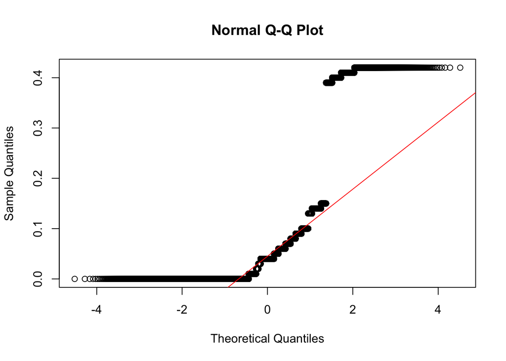

```r
qqnorm(hpv$cancer_rate)
qqline(hpv$cancer_rate, col= "red")
```

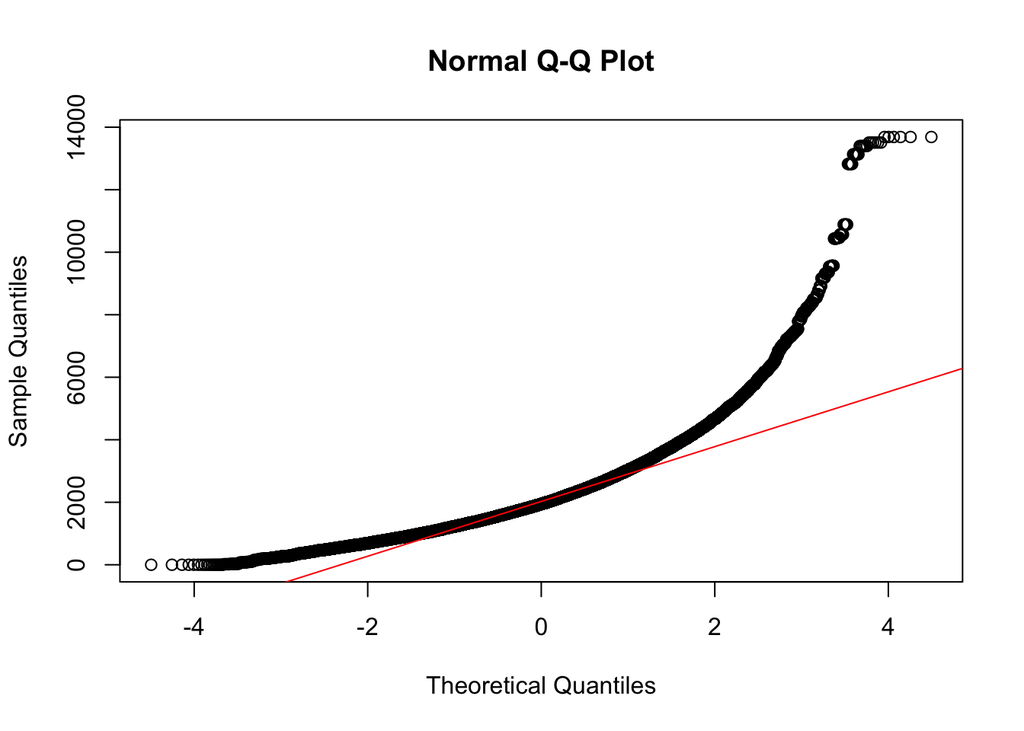

```r
qqnorm(hpv$kcal)
qqline(hpv$kcal , col = "red")
```

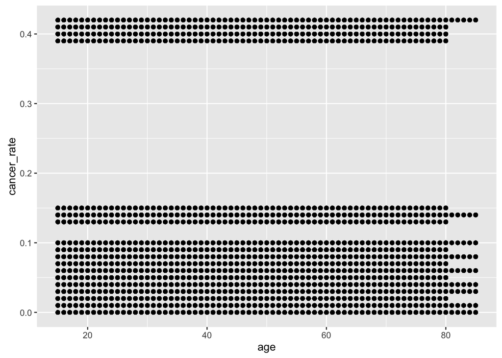

```r
hpv %>% ggplot(aes(age, cancer_rate)) + geom_point() + geom_abline()
```

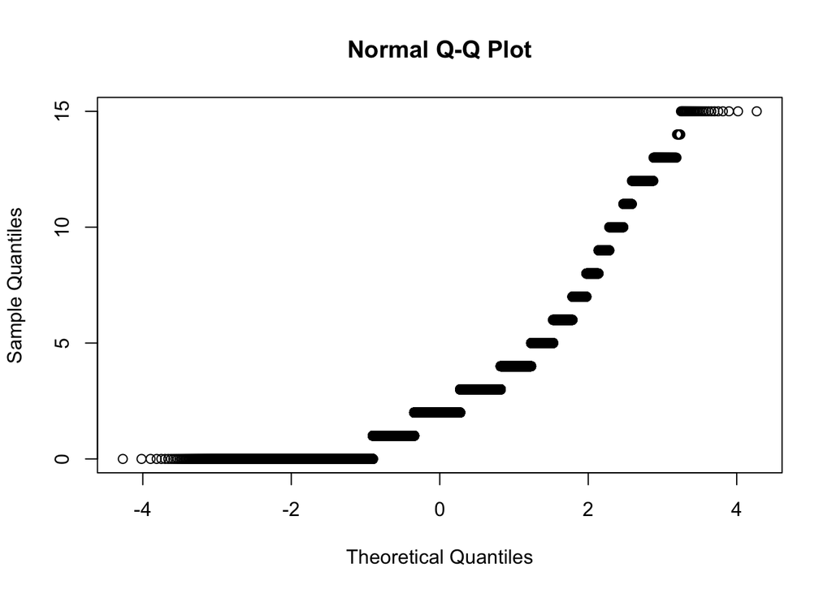

```r
qqnorm(hpv$numbirth)
```

## Logistic Regression:

```r
n <-glm( cbind(cancer_count, nocancer) ~ age + organ + c.hpv6 + c.hpv11 + c.hpv16 + c.hpv18 + c.hpv31 + c.hpv33 + c.hpv45 + c.hpv52 + c.hpv58 + c.oralhpv16 + race + numbirth + numpreg + smoke + education + marital_status + poverty_ratio + weightloss_lowcal_lowcarb_hipro + lowfat + lowNA + sugfree + lowfiber + hifiber + diabeticdiet + weightgain + othrediet + specialdiet + kcal, family = binomial, data = train_set)
summary(n)
```

```
##
## Call:
## glm(formula = cbind(cancer_count, nocancer) ~ age + organ + c.hpv6 +
##     c.hpv11 + c.hpv16 + c.hpv18 + c.hpv31 + c.hpv33 + c.hpv45 +
##     c.hpv52 + c.hpv58 + c.oralhpv16 + race + numbirth + numpreg +
##     smoke + education + marital_status + poverty_ratio + weightloss_lowcal_lowcarb_hipro +
##     lowfat + lowNA + sugfree + lowfiber + hifiber + diabeticdiet +
##     weightgain + othrediet + specialdiet + kcal, family = binomial,
##     data = train_set)
##
## Deviance Residuals:
##      Min        1Q    Median        3Q       Max
## -1.05744  -0.29991  -0.00007   0.19452   1.63459
##
## Coefficients: (7 not defined because of singularities)
##                                    Estimate Std. Error  z value Pr(>|z|)
## (Intercept)                      -1.132e+01  1.756e-02 -644.617   <2e-16
## age                              -9.130e-06  6.009e-05   -0.152    0.879
## organcervical                     1.429e+00  2.123e-03  673.189   <2e-16
## organoro                         -1.894e+00  5.242e-03 -361.366   <2e-16
## organpenile                      -2.043e+01  3.966e+02   -0.052    0.959
## organvaginal                     -1.011e+00  3.690e-03 -274.043   <2e-16
## organvulvar                       3.672e-01  2.487e-03  147.608   <2e-16
## c.hpv6                            1.228e-01  9.988e-03   12.294   <2e-16
## c.hpv11                          -1.540e-02  7.475e-04  -20.606   <2e-16
## c.hpv16                          -5.729e-02  4.674e-03  -12.256   <2e-16
## c.hpv18                                  NA         NA       NA       NA
## c.hpv31                                  NA         NA       NA       NA
## c.hpv33                                  NA         NA       NA       NA
## c.hpv45                                  NA         NA       NA       NA
## c.hpv52                                  NA         NA       NA       NA
## c.hpv58                                  NA         NA       NA       NA
## c.oralhpv16                              NA         NA       NA       NA
## race2                             7.753e-05  3.559e-03    0.022    0.983
## race3                             8.082e-05  2.508e-03    0.032    0.974
## race4                            -2.896e-04  2.835e-03   -0.102    0.919
## race5                            -5.182e-05  4.299e-03   -0.012    0.990
## numbirth                          1.088e-04  5.867e-04    0.185    0.853
## numpreg                           1.012e-04  4.961e-04    0.204    0.838
## smoke2                            5.708e-04  3.101e-03    0.184    0.854
```

[output cut: 69 more lines]

```
## weightgain1
## othrediet1
## specialdiet1
## kcal
## ---
## Signif. codes:  0 '***' 0.001 '**' 0.01 '*' 0.05 '.' 0.1 ' ' 1
##
## (Dispersion parameter for binomial family taken to be 1)
##
##     Null deviance: 2565419.1  on 14479  degrees of freedom
## Residual deviance:    3496.6  on 14439  degrees of freedom
##   (112750 observations deleted due to missingness)
## AIC: 80070
##
## Number of Fisher Scoring iterations: 15
```

```r
## Turning the types of hpv into categorical:
train_set <- train_set %>% gather(all_hpv, hpv_count, c.hpv6:c.oralhpv16)

n1 <- glm( cbind(cancer_count, nocancer) ~ age + organ +  all_hpv + hpv_count + race + numbirth + numpreg + smoke + education + marital_status + poverty_ratio + specialdiet + kcal, family = binomial, data = train_set)
summary(n1)
```

```
##
## Call:
## glm(formula = cbind(cancer_count, nocancer) ~ age + organ + all_hpv +
##     hpv_count + race + numbirth + numpreg + smoke + education +
##     marital_status + poverty_ratio + specialdiet + kcal, family = binomial,
##     data = train_set)
##
## Deviance Residuals:
##      Min        1Q    Median        3Q       Max
## -1.01156  -0.35127  -0.00007   0.29233   1.67779
##
## Coefficients:
##                      Estimate Std. Error   z value Pr(>|z|)
## (Intercept)        -1.154e+01  1.773e-03 -6510.607  < 2e-16 ***
## age                -6.910e-05  1.884e-05    -3.667 0.000246 ***
## organcervical       1.429e+00  6.712e-04  2129.037  < 2e-16 ***
## organoro           -1.895e+00  1.658e-03 -1143.038  < 2e-16 ***
## organpenile        -2.043e+01  1.254e+02    -0.163 0.870573
## organvaginal       -1.011e+00  1.167e-03  -866.451  < 2e-16 ***
## organvulvar         3.673e-01  7.865e-04   466.941  < 2e-16 ***
## all_hpvc.hpv16     -1.691e-02  2.026e-03    -8.342  < 2e-16 ***
## all_hpvc.hpv18     -6.883e-03  1.236e-03    -5.567 2.59e-08 ***
## all_hpvc.hpv31     -7.479e-03  1.273e-03    -5.873 4.28e-09 ***
## all_hpvc.hpv33     -1.797e-03  1.025e-03    -1.753 0.079621 .
## all_hpvc.hpv45     -7.001e-03  1.243e-03    -5.631 1.80e-08 ***
## all_hpvc.hpv52     -1.304e-02  1.689e-03    -7.717 1.19e-14 ***
## all_hpvc.hpv58     -6.617e-03  1.220e-03    -5.422 5.90e-08 ***
## all_hpvc.hpv6      -7.128e-03  1.251e-03    -5.697 1.22e-08 ***
## all_hpvc.oralhpv16 -3.486e-03  1.072e-03    -3.253 0.001143 **
## hpv_count           2.008e-04  2.087e-05     9.618  < 2e-16 ***
## race2              -5.598e-03  1.118e-03    -5.006 5.56e-07 ***
## race3              -1.087e-03  7.914e-04    -1.373 0.169705
## race4              -7.240e-04  8.935e-04    -0.810 0.417775
## race5               6.735e-04  1.344e-03     0.501 0.616357
## numbirth            2.670e-04  1.851e-04     1.443 0.149082
## numpreg             2.861e-04  1.564e-04     1.830 0.067298 .
## smoke2             -1.261e-04  9.797e-04    -0.129 0.897559
## smoke3              7.803e-04  5.314e-04     1.468 0.142008
## education2         -2.726e-04  9.848e-04    -0.277 0.781939
## education3          2.015e-03  9.767e-04     2.063 0.039151 *
```

[output cut: 8 more lines]

```
## marital_status77   -1.685e-02  8.213e-03    -2.051 0.040263 *
## poverty_ratio       6.262e-04  1.728e-04     3.623 0.000291 ***
## specialdiet1        5.313e-04  6.094e-04     0.872 0.383316
## kcal                1.172e-06  2.866e-07     4.091 4.30e-05 ***
## ---
## Signif. codes:  0 '***' 0.001 '**' 0.01 '*' 0.05 '.' 0.1 ' ' 1
##
## (Dispersion parameter for binomial family taken to be 1)
##
##     Null deviance: 25654191  on 144799  degrees of freedom
## Residual deviance:    39456  on 144761  degrees of freedom
##   (1127500 observations deleted due to missingness)
## AIC: 804453
##
## Number of Fisher Scoring iterations: 15
```

```r
## drop1(n1, test="Chisq")       "It takes time to run!"

## running the regression for only people who smoke:
train_set$yessmoke <- train_set$smoke == c("1", "2")

n2 <- glm( cbind(cancer_count, nocancer) ~ age + organ + all_hpv + hpv_count + race + numbirth + numpreg + yessmoke + education + marital_status + poverty_ratio + specialdiet + kcal, family = binomial, data = train_set)
summary(n2)
```

```
##
## Call:
## glm(formula = cbind(cancer_count, nocancer) ~ age + organ + all_hpv +
##     hpv_count + race + numbirth + numpreg + yessmoke + education +
##     marital_status + poverty_ratio + specialdiet + kcal, family = binomial,
##     data = train_set)
##
## Deviance Residuals:
##      Min        1Q    Median        3Q       Max
## -1.00770  -0.35139  -0.00007   0.29229   1.67834
##
## Coefficients:
##                      Estimate Std. Error   z value Pr(>|z|)
## (Intercept)        -1.154e+01  1.776e-03 -6500.018  < 2e-16 ***
## age                -6.427e-05  1.836e-05    -3.501 0.000464 ***
## organcervical       1.429e+00  6.712e-04  2128.958  < 2e-16 ***
## organoro           -1.895e+00  1.658e-03 -1143.040  < 2e-16 ***
## organpenile        -2.043e+01  1.254e+02    -0.163 0.870573
## organvaginal       -1.011e+00  1.167e-03  -866.459  < 2e-16 ***
## organvulvar         3.673e-01  7.865e-04   466.934  < 2e-16 ***
## all_hpvc.hpv16     -1.690e-02  2.026e-03    -8.342  < 2e-16 ***
## all_hpvc.hpv18     -6.882e-03  1.236e-03    -5.567 2.59e-08 ***
## all_hpvc.hpv31     -7.478e-03  1.273e-03    -5.872 4.29e-09 ***
## all_hpvc.hpv33     -1.797e-03  1.025e-03    -1.753 0.079644 .
## all_hpvc.hpv45     -7.000e-03  1.243e-03    -5.630 1.80e-08 ***
## all_hpvc.hpv52     -1.304e-02  1.689e-03    -7.717 1.19e-14 ***
## all_hpvc.hpv58     -6.617e-03  1.220e-03    -5.421 5.91e-08 ***
## all_hpvc.hpv6      -7.128e-03  1.251e-03    -5.697 1.22e-08 ***
## all_hpvc.oralhpv16 -3.485e-03  1.072e-03    -3.253 0.001144 **
## hpv_count           2.007e-04  2.087e-05     9.617  < 2e-16 ***
## race2              -5.616e-03  1.118e-03    -5.025 5.05e-07 ***
## race3              -1.137e-03  7.866e-04    -1.445 0.148454
## race4              -7.946e-04  8.910e-04    -0.892 0.372491
## race5               6.256e-04  1.342e-03     0.466 0.641110
## numbirth            2.678e-04  1.851e-04     1.447 0.147858
## numpreg             2.827e-04  1.562e-04     1.810 0.070253 .
## yessmokeTRUE       -6.185e-04  5.538e-04    -1.117 0.264000
## education2         -3.460e-04  9.828e-04    -0.352 0.724762
## education3          1.959e-03  9.756e-04     2.008 0.044644 *
## education4          7.913e-04  9.813e-04     0.806 0.420024
## education5         -1.325e-04  1.134e-03    -0.117 0.906991
## education7         -1.233e-02  1.143e-02    -1.079 0.280453
## marital_status2     5.446e-04  7.893e-04     0.690 0.490184
## marital_status3    -1.356e-03  6.552e-04    -2.069 0.038551 *
## marital_status4    -1.661e-03  1.130e-03    -1.470 0.141637
## marital_status5    -5.431e-04  8.394e-04    -0.647 0.517597
## marital_status6    -6.890e-04  8.827e-04    -0.781 0.435026
## marital_status77   -1.658e-02  8.210e-03    -2.019 0.043482 *
## poverty_ratio       6.481e-04  1.717e-04     3.774 0.000161 ***
## specialdiet1        5.917e-04  6.071e-04     0.975 0.329728
## kcal                1.185e-06  2.865e-07     4.138 3.50e-05 ***
## ---
## Signif. codes:  0 '***' 0.001 '**' 0.01 '*' 0.05 '.' 0.1 ' ' 1
##
## (Dispersion parameter for binomial family taken to be 1)
##
##     Null deviance: 25654191  on 144799  degrees of freedom
## Residual deviance:    39457  on 144762  degrees of freedom
##   (1127500 observations deleted due to missingness)
## AIC: 804452
##
## Number of Fisher Scoring iterations: 15
```

```r
## running the regression for only people who don't have any college level education:
train_set$nocollege <- train_set$education == c("1", "2")

n3 <- glm( cbind(cancer_count, nocancer) ~ age + organ + all_hpv + hpv_count + race + numbirth + numpreg + yessmoke + nocollege + marital_status + poverty_ratio + specialdiet + kcal, family = binomial, data = train_set)
summary(n3)
```

```
##
## Call:
## glm(formula = cbind(cancer_count, nocancer) ~ age + organ + all_hpv +
##     hpv_count + race + numbirth + numpreg + yessmoke + nocollege +
##     marital_status + poverty_ratio + specialdiet + kcal, family = binomial,
##     data = train_set)
##
## Deviance Residuals:
##      Min        1Q    Median        3Q       Max
## -1.02008  -0.35152  -0.00007   0.29243   1.67529
##
## Coefficients:
##                      Estimate Std. Error   z value Pr(>|z|)
## (Intercept)        -1.154e+01  1.644e-03 -7017.996  < 2e-16 ***
## age                -6.525e-05  1.828e-05    -3.571 0.000356 ***
## organcervical       1.429e+00  6.712e-04  2128.964  < 2e-16 ***
## organoro           -1.895e+00  1.658e-03 -1143.052  < 2e-16 ***
## organpenile        -2.043e+01  1.254e+02    -0.163 0.870573
## organvaginal       -1.011e+00  1.167e-03  -866.458  < 2e-16 ***
## organvulvar         3.673e-01  7.865e-04   466.947  < 2e-16 ***
## all_hpvc.hpv16     -1.689e-02  2.026e-03    -8.337  < 2e-16 ***
## all_hpvc.hpv18     -6.877e-03  1.236e-03    -5.563 2.65e-08 ***
## all_hpvc.hpv31     -7.473e-03  1.273e-03    -5.869 4.40e-09 ***
## all_hpvc.hpv33     -1.796e-03  1.025e-03    -1.751 0.079865 .
## all_hpvc.hpv45     -6.995e-03  1.243e-03    -5.626 1.84e-08 ***
## all_hpvc.hpv52     -1.303e-02  1.689e-03    -7.712 1.24e-14 ***
## all_hpvc.hpv58     -6.612e-03  1.220e-03    -5.418 6.03e-08 ***
## all_hpvc.hpv6      -7.122e-03  1.251e-03    -5.693 1.25e-08 ***
## all_hpvc.oralhpv16 -3.483e-03  1.072e-03    -3.250 0.001153 **
## hpv_count           2.006e-04  2.087e-05     9.612  < 2e-16 ***
## race2              -5.647e-03  1.113e-03    -5.073 3.92e-07 ***
## race3              -9.925e-04  7.603e-04    -1.305 0.191734
## race4              -7.378e-04  8.645e-04    -0.853 0.393431
## race5               5.602e-04  1.329e-03     0.422 0.673333
## numbirth            2.597e-04  1.838e-04     1.412 0.157843
## numpreg             2.719e-04  1.561e-04     1.742 0.081485 .
## yessmokeTRUE       -6.223e-04  5.551e-04    -1.121 0.262289
## nocollegeTRUE      -5.733e-04  6.616e-04    -0.867 0.386128
## marital_status2     4.757e-04  7.884e-04     0.603 0.546250
## marital_status3    -1.486e-03  6.513e-04    -2.281 0.022544 *
## marital_status4    -1.807e-03  1.129e-03    -1.601 0.109452
## marital_status5    -6.093e-04  8.390e-04    -0.726 0.467722
## marital_status6    -7.179e-04  8.825e-04    -0.814 0.415905
## marital_status77   -1.658e-02  8.204e-03    -2.021 0.043272 *
## poverty_ratio       6.063e-04  1.607e-04     3.773 0.000161 ***
## specialdiet1        5.573e-04  6.056e-04     0.920 0.357429
## kcal                1.139e-06  2.858e-07     3.985 6.76e-05 ***
## ---
## Signif. codes:  0 '***' 0.001 '**' 0.01 '*' 0.05 '.' 0.1 ' ' 1
##
## (Dispersion parameter for binomial family taken to be 1)
##
##     Null deviance: 25654191  on 144799  degrees of freedom
## Residual deviance:    39473  on 144766  degrees of freedom
##   (1127500 observations deleted due to missingness)
## AIC: 804459
##
## Number of Fisher Scoring iterations: 15
```

```r
## running the regression for  people who are not married:
train_set$notmarried <- train_set$marital_status != "1"

n4 <- glm( cbind(cancer_count, nocancer) ~ age + organ + all_hpv + hpv_count + race + numbirth + numpreg + yessmoke + nocollege + notmarried + poverty_ratio + specialdiet + kcal, family = binomial, data = train_set)
summary(n4)
```

```
##
## Call:
## glm(formula = cbind(cancer_count, nocancer) ~ age + organ + all_hpv +
##     hpv_count + race + numbirth + numpreg + yessmoke + nocollege +
##     notmarried + poverty_ratio + specialdiet + kcal, family = binomial,
##     data = train_set)
##
## Deviance Residuals:
##      Min        1Q    Median        3Q       Max
## -1.00935  -0.35168  -0.00007   0.29271   1.67630
##
## Coefficients:
##                      Estimate Std. Error   z value Pr(>|z|)
## (Intercept)        -1.154e+01  1.582e-03 -7297.499  < 2e-16 ***
## age                -5.604e-05  1.595e-05    -3.514 0.000442 ***
## organcervical       1.429e+00  6.711e-04  2129.186  < 2e-16 ***
## organoro           -1.895e+00  1.658e-03 -1143.062  < 2e-16 ***
## organpenile        -2.043e+01  1.254e+02    -0.163 0.870573
## organvaginal       -1.011e+00  1.167e-03  -866.465  < 2e-16 ***
## organvulvar         3.673e-01  7.865e-04   466.974  < 2e-16 ***
## all_hpvc.hpv16     -1.690e-02  2.026e-03    -8.341  < 2e-16 ***
## all_hpvc.hpv18     -6.880e-03  1.236e-03    -5.566 2.61e-08 ***
## all_hpvc.hpv31     -7.476e-03  1.273e-03    -5.871 4.32e-09 ***
## all_hpvc.hpv33     -1.796e-03  1.025e-03    -1.752 0.079728 .
## all_hpvc.hpv45     -6.998e-03  1.243e-03    -5.629 1.81e-08 ***
## all_hpvc.hpv52     -1.303e-02  1.689e-03    -7.716 1.20e-14 ***
## all_hpvc.hpv58     -6.615e-03  1.220e-03    -5.420 5.95e-08 ***
## all_hpvc.hpv6      -7.126e-03  1.251e-03    -5.696 1.23e-08 ***
## all_hpvc.oralhpv16 -3.484e-03  1.072e-03    -3.252 0.001146 **
## hpv_count           2.007e-04  2.087e-05     9.617  < 2e-16 ***
## race2              -5.669e-03  1.113e-03    -5.094 3.51e-07 ***
## race3              -9.694e-04  7.590e-04    -1.277 0.201560
## race4              -6.956e-04  8.590e-04    -0.810 0.418023
## race5               6.283e-04  1.328e-03     0.473 0.636065
## numbirth            3.056e-04  1.830e-04     1.670 0.094995 .
## numpreg             2.388e-04  1.557e-04     1.534 0.125050
## yessmokeTRUE       -6.305e-04  5.544e-04    -1.137 0.255448
## nocollegeTRUE      -4.803e-04  6.599e-04    -0.728 0.466695
## notmarriedTRUE     -7.889e-04  4.890e-04    -1.613 0.106681
## poverty_ratio       5.954e-04  1.604e-04     3.712 0.000206 ***
## specialdiet1        5.146e-04  6.051e-04     0.850 0.395085
## kcal                1.128e-06  2.856e-07     3.949 7.86e-05 ***
## ---
## Signif. codes:  0 '***' 0.001 '**' 0.01 '*' 0.05 '.' 0.1 ' ' 1
##
## (Dispersion parameter for binomial family taken to be 1)
##
##     Null deviance: 25654191  on 144799  degrees of freedom
## Residual deviance:    39483  on 144771  degrees of freedom
##   (1127500 observations deleted due to missingness)
## AIC: 804460
##
## Number of Fisher Scoring iterations: 15
```

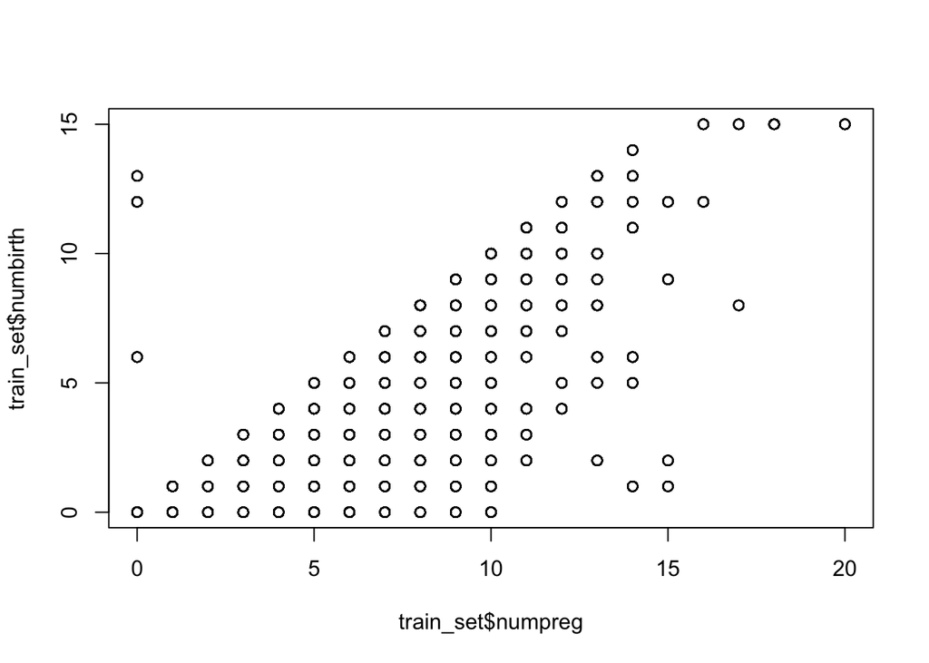

```r
## number of preg vs. number of birth:(these two are highly correlated and only one is needed)
## dimention reduction later will show the same conclusion

plot(train_set$numpreg, train_set$numbirth)
```